# Practice Code: Day 1

Author

Constantin Manuel Bosancianu

Published

November 1, 2015

# 1 Introduction

**Warning**: the code chunk below will install packages on your system (if these are not already installed).

```r
library(pacman)
p_load(tidyverse, survival, knitr, ggthemes)
```

We also load the Reinhart-Rogoff data.

```r
load("../02-data/01-RR-final.Rdata")
```

Finally, we include a pair of helpful functions to create plots for our survival analyses using `ggplot2`.[^1]

<sup>1</sup> The functions were created by Ramon Saccilotto, at the Basel Institute for Clinical Epidemiology and Biostatistics.

```r
createSurvivalFrame <- function(f.survfit){
# initialise frame variable
f.frame <- NULL
# check if more then one strata
if(length(names(f.survfit$strata)) == 0){
# create data.frame with data from survfit
f.frame <- data.frame(time=f.survfit$time, n.risk=f.survfit$n.risk, n.event=f.survfit$n.event, n.censor = f.survfit
$n.censor, surv=f.survfit$surv, upper=f.survfit$upper, lower=f.survfit$lower)
# create first two rows (start at 1)
f.start <- data.frame(time=c(0, f.frame$time[1]), n.risk=c(f.survfit$n, f.survfit$n), n.event=c(0,0),
n.censor=c(0,0), surv=c(1,1), upper=c(1,1), lower=c(1,1))
# add first row to dataset
f.frame <- rbind(f.start, f.frame)
# remove temporary data
rm(f.start)
}
else {
# create vector for strata identification
f.strata <- NULL
for(f.i in 1:length(f.survfit$strata)){
# add vector for one strata according to number of rows of strata
f.strata <- c(f.strata, rep(names(f.survfit$strata)[f.i], f.survfit$strata[f.i]))
}
# create data.frame with data from survfit (create column for strata)
f.frame <- data.frame(time=f.survfit$time, n.risk=f.survfit$n.risk, n.event=f.survfit$n.event, n.censor = f.survfit
$n.censor, surv=f.survfit$surv, upper=f.survfit$upper, lower=f.survfit$lower, strata=factor(f.strata))
# remove temporary data
rm(f.strata)
# create first two rows (start at 1) for each strata
for(f.i in 1:length(f.survfit$strata)){
# take only subset for this strata from data
f.subset <- subset(f.frame, strata==names(f.survfit$strata)[f.i])
# create first two rows (time: 0, time of first event)
f.start <- data.frame(time=c(0, f.subset$time[1]), n.risk=rep(f.survfit[f.i]$n, 2), n.event=c(0,0),
n.censor=c(0,0), surv=c(1,1), upper=c(1,1), lower=c(1,1), strata=rep(names(f.survfit$strata)[f.i],
2))
# add first two rows to dataset
f.frame <- rbind(f.start, f.frame)
# remove temporary data
rm(f.start, f.subset)
}
# reorder data
f.frame <- f.frame[order(f.frame$strata, f.frame$time), ]
# rename row.names
rownames(f.frame) <- NULL
}
# return frame
return(f.frame)
}


# define custom function to draw kaplan-meier curve with ggplot
qplot_survival <- function(f.frame, f.CI="default", f.shape=3){
# use different plotting commands dependig whether or not strata's are given
if("strata" %in% names(f.frame) == FALSE){
# confidence intervals are drawn if not specified otherwise
if(f.CI=="default" | f.CI==TRUE ){
# create plot with 4 layers (first 3 layers only events, last layer only censored)
# hint: censoring data for multiple censoring events at timepoint are overplotted
# (unlike in plot.survfit in survival package)
ggplot(data=f.frame) + geom_step(aes(x=time, y=surv), direction="hv") + geom_step(aes(x=time,
y=upper), directions="hv", linetype=2) + geom_step(aes(x=time,y=lower), direction="hv", linetype=2) +
geom_point(data=subset(f.frame, n.censor==1), aes(x=time, y=surv), shape=f.shape)
}
else {
# create plot without confidence intervals
ggplot(data=f.frame) + geom_step(aes(x=time, y=surv), direction="hv") +
geom_point(data=subset(f.frame, n.censor==1), aes(x=time, y=surv), shape=f.shape)
}
}
else {
if(f.CI=="default" | f.CI==FALSE){
# without CI
ggplot(data=f.frame, aes(group=strata, colour=strata)) + geom_step(aes(x=time, y=surv),
direction="hv") + geom_point(data=subset(f.frame, n.censor==1), aes(x=time, y=surv), shape=f.shape)
}
else {
# with CI (hint: use alpha for CI)
ggplot(data=f.frame, aes(colour=strata, group=strata)) + geom_step(aes(x=time, y=surv),
direction="hv") + geom_step(aes(x=time, y=upper), directions="hv", linetype=2, alpha=0.5) +
geom_step(aes(x=time,y=lower), direction="hv", linetype=2, alpha=0.5) +
geom_point(data=subset(f.frame, n.censor==1), aes(x=time, y=surv), shape=f.shape)
}
}
}
```

# 2 Data cleaning

We start with a bit of data cleaning and subsetting, based on the following rules:

1. We subset the data to just the 1980-2000 period
2. We construct 7 distinct time periods in the data, and aggregate it at the level of period;
3. We further dichotomize the indicator for sovereign debt crises: any country and period with at least 1 sovereign debt crisis is coded as **1**
4. The periods immediately following a period with a sovereign debt crisis are coded as **0**

```r
df_rr <- DFrr |>
  filter(year >= 1980 & year <= 2000) |>
  mutate(period = case_when(year >= 1980 & year <= 1982 ~ 1,
                            year >= 1983 & year <= 1985 ~ 2,
                            year >= 1986 & year <= 1988 ~ 3,
                            year >= 1989 & year <= 1991 ~ 4,
                            year >= 1992 & year <= 1994 ~ 5,
                            year >= 1995 & year <= 1997 ~ 6,
                            year >= 1998 & year <= 2000 ~ 7)) |>
  filter(country %in% c("Algeria", "Argentina", "Australia", "Brazil", "Canada",
                        "Chile", "China", "Ecuador", "El Salvador", "Ghana",
                        "Honduras", "India", "Indonesia", "Kenya", "Malaysia",
                        "Mexico", "Nicaragua", "Nigeria", "Panama", "Peru",
                        "Portugal", "Russia", "Sri Lanka", "Thailand",
                        "Turkey", "Venezuela", "Zimbabwe", "Philippines",
                        "Myanmar", "Bolivia", "Angola", "France", "Ireland",
                        "Greece", "Paraguay"))

df_temp <- df_rr |>
  group_by(country, period) |>
  summarise(cr_debt = sum(sovdebt1)) |>
  ungroup() |>
  mutate(cr_debt = if_else(cr_debt >= 2, 1, cr_debt),
         cr_debt = if_else(country == "Angola" & period >= 6, 0, cr_debt),
         cr_debt = if_else(country == "Argentina" & period >= 2, 0, cr_debt),
         cr_debt = if_else(country == "Bolivia" & period >= 2, 0, cr_debt),
         cr_debt = if_else(country == "Brazil" & period >= 4, 0, cr_debt),
         cr_debt = if_else(country == "El Salvador" & period >= 2, 0, cr_debt),
         cr_debt = if_else(country == "Indonesia" & period >= 7, 0, cr_debt),
         cr_debt = if_else(country == "Nicaragua" & period >= 3, 0, cr_debt),
         cr_debt = if_else(country == "Panama" & period >= 4, 0, cr_debt),
         cr_debt = if_else(country == "Peru" & period >= 3, 0, cr_debt),
         cr_debt = if_else(country == "Venezuela" & period >= 7, 0, cr_debt))
```

# 3 Examine data

How many sovereign debt crises take place in each period?

```r
df_temp |>
  group_by(period) |>
  summarise(cr_debt = sum(cr_debt)) |>
  rename(`Period of time` = 1,
         `Number of debt crises` = 2) |>
  kable(caption = "Summary of sovereign debt crises (1980-2000)")
```

Summary of sovereign debt crises (1980-2000)

| Period of time | Number of debt crises |
| --- | --- |
| 1 | 5 |
| 2 | 3 |
| 3 | 2 |
| 4 | 0 |
| 5 | 1 |
| 6 | 3 |
| 7 | 2 |

```r
rm(df_temp)
```

What is the survival time?

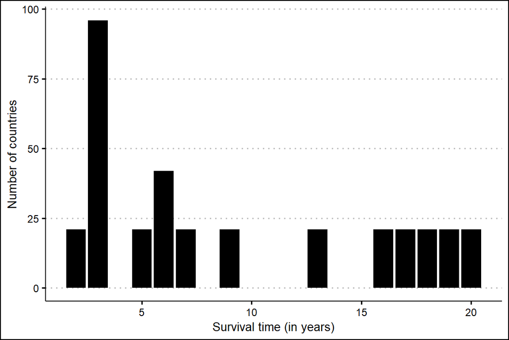

```r
df_agg <- df_rr |>
  dplyr::select(country, year, contin, sovdebt1) |>
  group_by(country) |>
  mutate(time = str_locate(paste(sovdebt1, collapse = ""), "1")[1]) |>
  ungroup()

ggplot(df_agg, aes(x = time)) +
  geom_bar(fill = "black") +
  labs(x = "Survival time (in years)",
       y = "Number of countries") +
  theme_clean()
```

If time is missing, that means the country is censored (did not have a crisis, e.g. Australia)

```r
df_fin <- df_agg |>
  group_by(country) |>
  summarise(time = time[1] - 1,
            contin = contin[1]) |>
  mutate(event = if_else(is.na(time), 0, 1),
         SouthA = if_else(contin == "South America", 1, 0),
         time = if_else(is.na(time), 19, time))
```

How the final data set looks.

```r
df_fin |> glimpse()
```

```
Rows: 35
Columns: 5
$ country <chr> "Algeria", "Angola", "Argentina", "Australia", "Bolivia", "Bra…
$ time    <dbl> 19, 12, 2, 19, 2, 6, 19, 19, 19, 19, 1, 19, 2, 19, 19, 19, 17,…
$ contin  <chr> "Africa", "Africa", "South America", "OECD", "South America", …
$ event   <dbl> 0, 1, 1, 0, 1, 1, 0, 0, 0, 1, 1, 0, 1, 0, 0, 0, 1, 0, 0, 0, 1,…
$ SouthA  <dbl> 0, 0, 1, 0, 1, 1, 0, 1, 0, 1, 0, 0, 0, 0, 0, 0, 0, 0, 0, 0, 0,…
```

# 4 Initial survival analysis

## 4.1 Basic

We first have to define a `survival` object, which is then used by the `survival` package’s functions.

The `type=` argument asks what kind of censoring we have in our data, with 6 options. `right` is the default, but I added it here nonetheless. Other common options are `left` or `interval`.[^2]

<sup>2</sup> `Surv()` technically creates an object which will be used as a DV by the multivariate procedures we will go through tomorrow.

Unless specifying variables, the `~ 1` part is the default. It technically means that the entire sample is used for 1 Kaplan-Meier curve.

Right censored observations are marked with a **+** in the output.

```r
Surv(df_fin$time, df_fin$event, type = "right")
```

```
 [1] 19+ 12   2  19+  2   6  19+ 19+ 19+ 19   1  19+  2  19+ 19+ 19+ 17  19+ 19+
[20] 19+  2   4   5  19+  8  19+  5  19+ 19+ 18  16  19+ 19+ 15  19+
```

```r
ObjSurv1 <- survfit(Surv(time, event) ~ 1, data = df_fin)
```

Display survival probabilities for each time point.

```r
round(summary(ObjSurv1)$surv, digits = 2)
```

```
 [1] 0.97 0.86 0.83 0.77 0.74 0.71 0.69 0.66 0.63 0.60 0.57 0.54
```

Display upper confidence bound for the survival estimates.[^3]

<sup>3</sup> This code can easily be adapted to get the lower confidence bound as well.

```r
round(summary(ObjSurv1)$upper, digits = 2)
```

```
 [1] 1.00 0.98 0.96 0.92 0.90 0.88 0.86 0.83 0.81 0.79 0.76 0.74
```

We can also easily plot survival estimates.

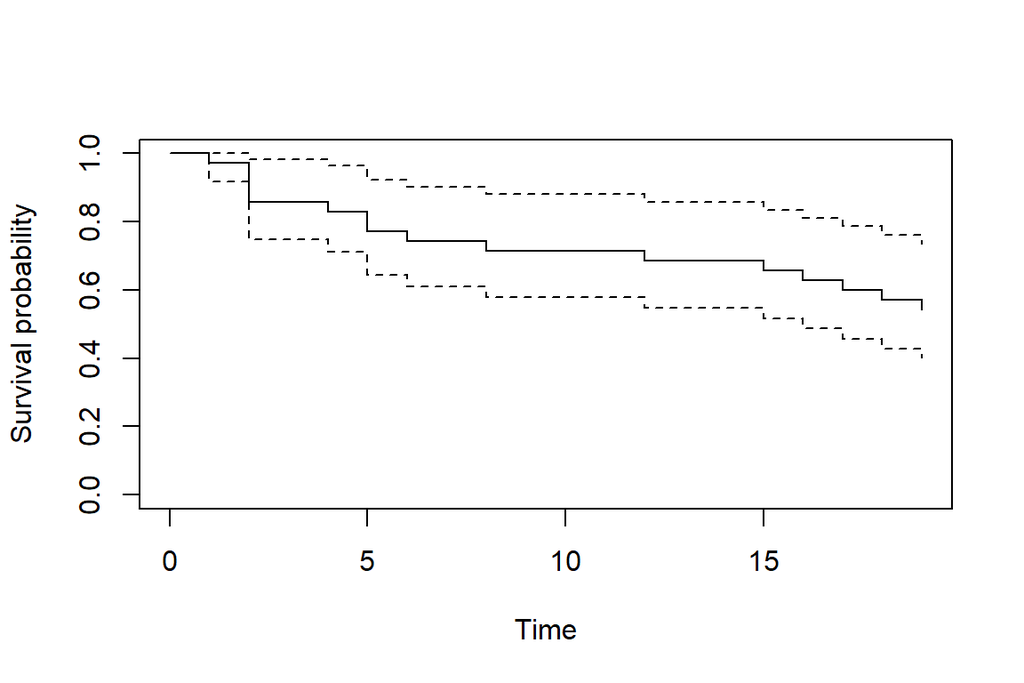

```r
plot(ObjSurv1,
     xlab = "Time",
     ylab = "Survival probability")
```

## 4.2 Separate groups

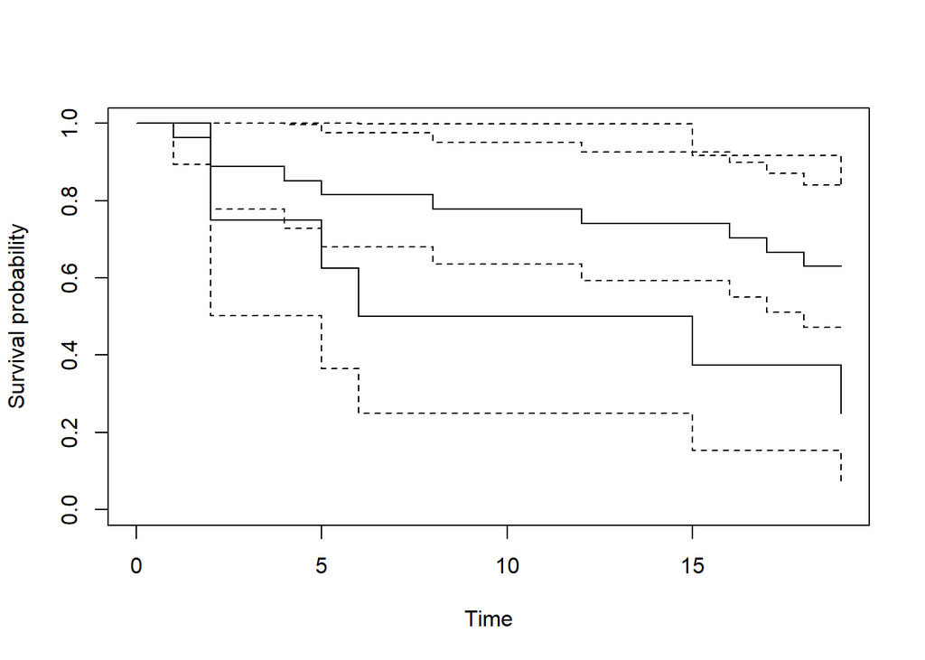

```r
ObjSurv2 <- survfit(Surv(time, event) ~ SouthA,
                    data = df_fin)

plot(ObjSurv2,
     xlab = "Time",
     ylab = "Survival probability",
     conf.int = TRUE)
```

We can get nicer plots by using the custom functions defined at the beginning of the script.

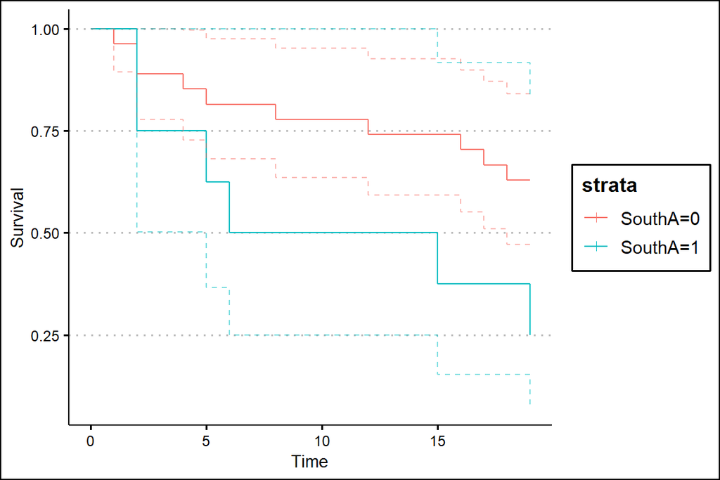

```r
# Apply the functions to this example
ObjSurvMod2 <- createSurvivalFrame(ObjSurv2)

qplot_survival(ObjSurvMod2, f.CI = TRUE) +
  labs(x = "Time",
       y = "Survival") +
  theme_clean()
```

# 5 Significance tests

Apply the log-rank test with the `survdiff()` function; this checks whether there is a significant difference between the two curves.

```r
survdiff(Surv(time, event) ~ SouthA,
         data = df_fin)
```

```
Call:
survdiff(formula = Surv(time, event) ~ SouthA, data = df_fin)

          N Observed Expected (O-E)^2/E (O-E)^2/V
SouthA=0 27       10    12.99     0.689      3.82
SouthA=1  8        6     3.01     2.973      3.82

 Chisq= 3.8  on 1 degrees of freedom, p= 0.05
```

We can also apply the Peto type of log-rank test, via the same function.

```r
survdiff(Surv(time, event) ~ SouthA,
         data = df_fin,
         rho = 1)
```

```
Call:
survdiff(formula = Surv(time, event) ~ SouthA, data = df_fin,
    rho = 1)

          N Observed Expected (O-E)^2/E (O-E)^2/V
SouthA=0 27     7.97    10.29     0.521      3.34
SouthA=1  8     4.80     2.49     2.155      3.34

 Chisq= 3.3  on 1 degrees of freedom, p= 0.07
```